# Didacticiel 03 - Générer des données factices à des fins pédagogiques avec fakir

Auteur·rice

Benoît MARION - master SEP

Date de publication

2 novembre 2023

[figure not shown]

Logo Fakir

# 1. Présentation

Aujourd’hui nous allons découvrir ensemble le package R nommé fakir. Après avoir présenté le package et ses objectifs, nous allons voir ce qu’il permet de faire en regardant de manière détaillée ses différentes fonctions. Finalement, nous verrons brièvement les autres solutions possibles pour créer des données utilisables dans un cadre pédagogique.

## 1.1 informations générales

Le package fakir a été développé par deux développeurs français [Colin Fay](https://colinfay.me/) (*maintainer*) et [Sebastien Rochette](https://statnmap.com/). La dernière version stable est la 1.0.0[^1]. Les informations générales, le manuel[^2], les *changelogs* et les liens vers les dépôts de fakir sont accessibles sur le [site du CRAN](https://cran.r-project.org/web/packages/fakir/index.html).

## 1.2 intérêt du package fakir

Ce package permet de créer des jeux données factices se rapprochant de ceux qui se trouvent dans un environnement réel (données de sondage, avis client …). Cela permet donc de travailler sur des données plus pertinentes pour des cas pratiques tout respectant la RGPD.

L’objectif est de permettre d’avoir facilement des *datasets* pour travailler la manipulation (`tidyverse` principalement)et la visualisation de données (`ggplot` ou `shiny`[^3]).

Ainsi, comme l’expliquent les auteurs sur le [wiki de fakir](https://thinkr-open.github.io/fakir/index.html):

> “Certains jeux de données suivent les principes du *tidy-data*, d’autres non. Certaines valeurs sont manquantes pour les données numériques et catégorielles. Certaines variables sont corrélées”

# 2. Utilisation pratique

## 2.1 installation et import

Pour installer fakir (comme pour tous les autres packages publiées sur le CRAN), utilisez l’onglet package dans RStudio ou lancez la fonction `install.packages("fakir")` dans la console R.

On importe le package (et quelques autres que nous utiliserons) dans notre espace de travail avec :

```r
library(fakir)
library(dplyr)
library(ggplot2)
```

## 2.2 liste des fonctions disponibles dans le pacakge

Ci-dessous, nous pouvons-voir les différentes fonctions accessibles [^4] grâce au package fakir et leur arguments (plus d’informations sur ces derniers dans le pdf ou avec la commande `?fake_...`).

```r
lsf.str("package:fakir")
```

```
%>% : function (lhs, rhs)
fake_base_clients : function (n, local = c("en_US", "fr_FR"), seed = 2811)
fake_products : function (n, seed = 2811)
fake_sondage_answers : function (...)
fake_sondage_people : function (...)
fake_survey_answers : function (n = 200, x, seed = 2811, split = FALSE, local = c("fr_FR"))
fake_survey_people : function (n, seed = 2811, local = c("fr_FR"))
fake_ticket_client : function (vol, x, n = 200, split = FALSE, seed = 2811, local = c("en_US",
    "fr_FR"))
fake_user_feedback : function (n, seed = 2811, from = "2012-01-01 00:00:01", to = "2020-01-01 00:00:01")
fake_visits : function (from = "2017-01-01", to = "2017-12-31", local = c("en_US", "fr_FR"),
    seed = 2811)
```

## 2.3 génération des jeux de données, description des paramètres et début d’analyse visuelles

### 2.3.1 `fake_product()`

Cette fonction dispose de deux arguments `n` et la `seed` et nous renvoie une liste de produits factices.

```r
products <- fake_products(1000, seed = 2023)
products
```

```
# A tibble: 1,000 × 8
   name                 brand color price body_location category sent_from    id
   <chr>                <chr> <chr> <int> <chr>         <chr>    <chr>     <int>
 1 Multifunction Track… Bern… Yell…   721 Arms          Lifesty… Italy         1
 2 Footpod IN           Bern… Olive   172 Brain         Fitness  Japan         2
 3 Running Tracker LI … Paco… Corn…   698 Head          Medical  Italy         3
 4 Wearable Transmitte… Haye… Gold    399 Arms          Fitness  South Ko…     4
 5 Footpod              Klei… Dark…   312 Feet          Awesome  Japan         5
 6 Activity Tracker ER… Haye… Crim…   960 Brain         Medical  Austria       6
 7 Running Tracker Pro… Wyma… Peac…    37 Chest         Enterta… France        7
 8 Loop Activity Track… Klei… Dark…    35 Wrist         Awesome  South Ko…     8
 9 Fitness Tracker BHC… Hamm… Black   764 Waist         Industr… Italy         9
10 Biking Tracker GE    Webe… Nava…   862 Arms          Pets an… United S…    10
# ℹ 990 more rows
```

```r
summary(products)
```

```
     name              brand              color               price
 Length:1000        Length:1000        Length:1000        Min.   :  2.0
 Class :character   Class :character   Class :character   1st Qu.:253.2
 Mode  :character   Mode  :character   Mode  :character   Median :518.5
                                                          Mean   :506.1
                                                          3rd Qu.:763.2
                                                          Max.   :999.0
 body_location        category          sent_from               id
 Length:1000        Length:1000        Length:1000        Min.   :   1.0
 Class :character   Class :character   Class :character   1st Qu.: 250.8
 Mode  :character   Mode  :character   Mode  :character   Median : 500.5
                                                          Mean   : 500.5
                                                          3rd Qu.: 750.2
                                                          Max.   :1000.0
```

Le jeu de données renvoyé est un `tibble` et ressemble à une liste relativement réaliste d’équipements connectés en vente avec des infos sur la marque, la catégorie, le prix, la couleur et la provenance.

On peut ainsi regarder le nombre de produits par marque :

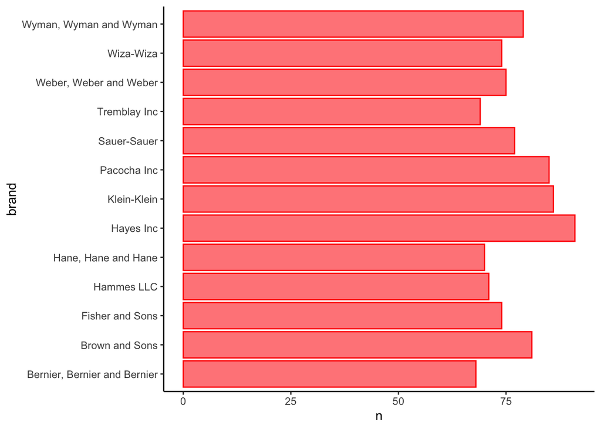

```r
products %>%
  count(brand)  %>%
  arrange(desc(n)) %>%
  ggplot() + geom_col(aes(x = n, y = brand), alpha = .8, fill = "#FF6666", colour = "red") + theme_classic()
```

Les données de prix sont relativement peu exploitables dans un cadre analytique (ne semblent pas corréelées au type de produit) et ressemblent à échantillon de loi uniforme allant de 0 au `n` choisi.

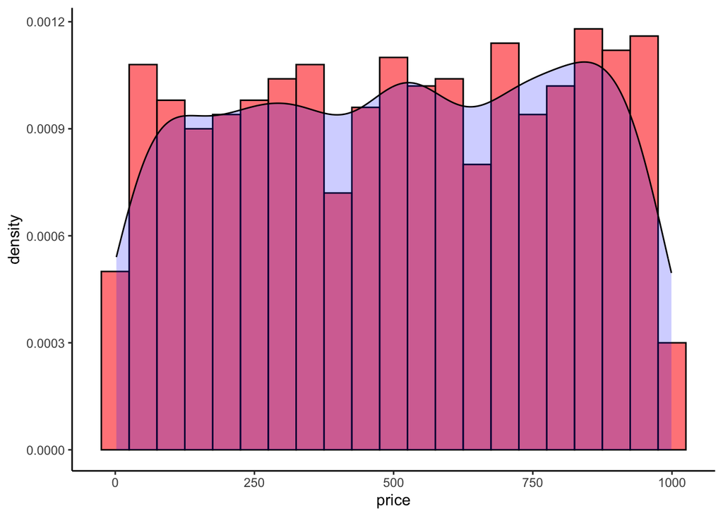

```r
ggplot(products, aes(x = price)) +
geom_histogram(aes(y = after_stat(density)), colour="black", alpha = .8, fill="#FF6666", binwidth=50) +
geom_density(alpha = .2, fill = "blue") + theme_classic()
```

On peut évidemment changer le `n` choisi pour avoir plus de données, la commande génère le nouveau *dataset* relativement rapidement (même pour `n = 10000`).

```r
fake_products(1000, seed = 2023)
```

```
# A tibble: 1,000 × 8
   name                 brand color price body_location category sent_from    id
   <chr>                <chr> <chr> <int> <chr>         <chr>    <chr>     <int>
 1 Multifunction Track… Bern… Yell…   721 Arms          Lifesty… Italy         1
 2 Footpod IN           Bern… Olive   172 Brain         Fitness  Japan         2
 3 Running Tracker LI … Paco… Corn…   698 Head          Medical  Italy         3
 4 Wearable Transmitte… Haye… Gold    399 Arms          Fitness  South Ko…     4
 5 Footpod              Klei… Dark…   312 Feet          Awesome  Japan         5
 6 Activity Tracker ER… Haye… Crim…   960 Brain         Medical  Austria       6
 7 Running Tracker Pro… Wyma… Peac…    37 Chest         Enterta… France        7
 8 Loop Activity Track… Klei… Dark…    35 Wrist         Awesome  South Ko…     8
 9 Fitness Tracker BHC… Hamm… Black   764 Waist         Industr… Italy         9
10 Biking Tracker GE    Webe… Nava…   862 Arms          Pets an… United S…    10
# ℹ 990 more rows
```

```r
fake_products(1000, seed = 1999)
```

```
# A tibble: 1,000 × 8
   name                 brand color price body_location category sent_from    id
   <chr>                <chr> <chr> <int> <chr>         <chr>    <chr>     <int>
 1 Activity Monitor SN  Koze… Fuch…   240 Arms          Enterta… Taiwan        1
 2 Wearable Transmitte… Coll… Dark…   790 Torso         Industr… Italy         2
 3 Exercise Tracker ES  Stie… Ligh…   695 Torso         Fitness  France        3
 4 Running Tracker      Schm… Khaki   970 Neck          Fitness  France        4
 5 Wearable Transmitte… Vand… Yell…   402 Feet          Gaming   Canada        5
 6 Training System      Coll… HotP…   600 Arms          Medical  Italy         6
 7 Loop Activity Track… Absh… Ligh…   368 Arms          Fitness  Finland       7
 8 Wearable Transmitte… Stie… Coral   567 Wrist         Medical  China         8
 9 Watch SCLV           Olso… White   872 Wrist         Fitness  China         9
10 Wearable Transmitte… Koze… Cade…   637 Wrist         Awesome  Austria      10
# ℹ 990 more rows
```

```r
fake_products(10000, seed = 2023)
```

```
# A tibble: 10,000 × 8
   name                 brand color price body_location category sent_from    id
   <chr>                <chr> <chr> <int> <chr>         <chr>    <chr>     <int>
 1 Multifunction Track… Wuns… Dodg…  9327 Hands         Industr… Italy         1
 2 Footpod IN           Bode… Dark…  3276 Torso         Fitness  China         2
 3 Running Tracker LI … John… Ligh…  1810 Hands         Fitness  Austria       3
 4 Wearable Transmitte… John… Teal   2177 Arms          Enterta… Netherla…     4
 5 Footpod              Jenk… Medi…  9693 Neck          Enterta… United S…     5
 6 Activity Tracker ER… Bloc… Midn…  1957 Torso         Pets an… Canada        6
 7 Running Tracker Pro… Schm… Pale…  1418 Waist         Lifesty… United S…     7
 8 Loop Activity Track… Wuns… Lemo…  5726 Hands         Gaming   Canada        8
 9 Fitness Tracker BHC… John… Fore…  9958 Arms          Fitness  Finland       9
10 Biking Tracker GE    Vand… Alic…  2711 Head          Pets an… Japan        10
# ℹ 9,990 more rows
```

Le nom des marques change (aussi si l’on change la graine) mais le nombre total de marques différentes ne paraît jamais dépasser 13-14.

### 2.3.2 `fake_visit()`

Cette fonction nous renvoie une base de données temporelles listant les visites sur un site internet. Contrairement au reste des fonctions du package `fake_visit()`, il ne dispose pas de paramètre `n` mais de la date de début et de fin.

```r
visits <- fake_visits(from = "2022-01-01", to = "2022-12-31", seed = 2023, local = "en_US")
visits
```

```
# A tibble: 365 × 8
   timestamp   year month   day  home about  blog contact
 * <date>     <dbl> <dbl> <int> <int> <int> <int>   <int>
 1 2022-01-01  2022     1     1    NA   185   499     158
 2 2022-01-02  2022     1     2   460    NA   463     394
 3 2022-01-03  2022     1     3   342   119   359     281
 4 2022-01-04  2022     1     4   381   260   502     468
 5 2022-01-05  2022     1     5    NA   291   460     262
 6 2022-01-06  2022     1     6   453   284    NA     101
 7 2022-01-07  2022     1     7    NA   198   439     226
 8 2022-01-08  2022     1     8   128    NA   366     172
 9 2022-01-09  2022     1     9   148    NA   324      NA
10 2022-01-10  2022     1    10   480    NA   372      75
# ℹ 355 more rows
```

```r
summary(visits)
```

```
   timestamp               year          month             day
 Min.   :2022-01-01   Min.   :2022   Min.   : 1.000   Min.   : 1.00
 1st Qu.:2022-04-02   1st Qu.:2022   1st Qu.: 4.000   1st Qu.: 8.00
 Median :2022-07-02   Median :2022   Median : 7.000   Median :16.00
 Mean   :2022-07-02   Mean   :2022   Mean   : 6.526   Mean   :15.72
 3rd Qu.:2022-10-01   3rd Qu.:2022   3rd Qu.:10.000   3rd Qu.:23.00
 Max.   :2022-12-31   Max.   :2022   Max.   :12.000   Max.   :31.00

      home           about            blog          contact
 Min.   :101.0   Min.   : 50.0   Min.   :300.0   Min.   : 53.0
 1st Qu.:211.5   1st Qu.:103.5   1st Qu.:416.0   1st Qu.:153.5
 Median :298.0   Median :176.0   Median :514.0   Median :272.0
 Mean   :303.9   Mean   :175.5   Mean   :507.6   Mean   :270.4
 3rd Qu.:403.0   3rd Qu.:244.0   3rd Qu.:602.0   3rd Qu.:386.0
 Max.   :499.0   Max.   :298.0   Max.   :700.0   Max.   :500.0
 NA's   :26      NA's   :122     NA's   :36      NA's   :18
```

On voit beaucoup de valeurs manquantes dans les colonnes, ce qui permet de travailler la gestion de celles-ci. Les données se composent d’une date et de 4 variables aléatoires censées représenter les visites aux différentes pages du site web.

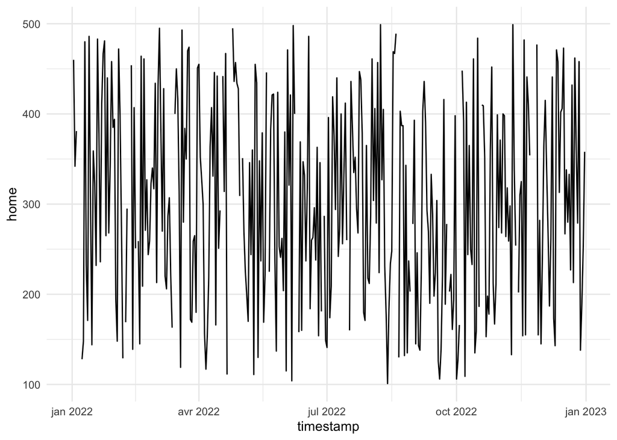

```r
ggplot(visits, aes(x=timestamp, y=home)) +
  geom_line() + theme_minimal()
```

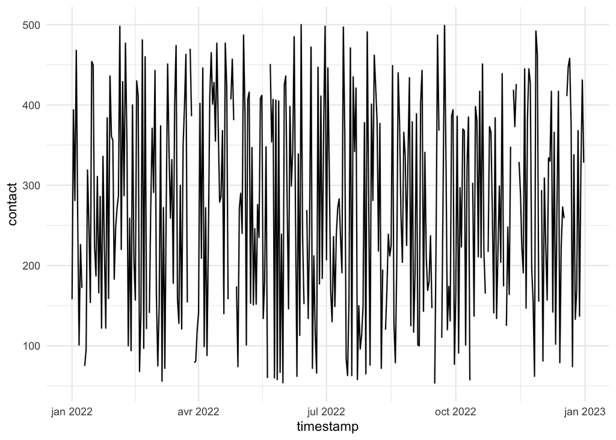

```r
ggplot(visits, aes(x=timestamp, y=contact)) +
  geom_line() + theme_minimal()
```

Les données ressemblent à des séries temporelles stationnaires avec une variablilité relativement importante. Elles permettent de travailler les différentes techniques de modélisation et de visualisation des données temporelles.

### 2.3.3 `fake_user_feedback()`

Cette fonction nous renvoie un *dataset* d’évaluations de clients. Elle dispose de 4 arguments `n`, `seed` et la date de début et de fin (délimite la période des retours clients mais n’influence pas le `n`).

```r
usr_feedback <- fake_user_feedback(1000, seed = 2023, from = "2022-01-01 00:00:01", to = "2023-01-01 00:00:00")
head(usr_feedback, 10)
```

```
                     user star                date
1       Mr. Hamza Windler    2 2022-07-05 12:54:56
2      Devante Jakubowski    3 2022-02-07 10:11:27
3        Kirk Gottlieb MD    3 2022-03-29 04:42:31
4       Genevieve Kerluke    5 2022-06-21 11:10:11
5          Junior Kovacek    5 2022-10-13 14:43:07
6         Bama McLaughlin    3 2022-06-01 13:54:02
7  Miss Logan Sanford DDS    1 2022-05-07 12:36:34
8    Cressie Hermann-Lang    4 2022-02-03 14:42:57
9      Ms. Joanne Mueller    2 2022-03-05 05:35:29
10        Dijon Nader Jr.    3 2022-10-28 08:46:53
```

```r
summary(usr_feedback)
```

```
     user                star            date
 Length:1000        Min.   :1.000   Min.   :2022-01-01 02:43:27.00
 Class :character   1st Qu.:2.000   1st Qu.:2022-03-31 01:38:24.50
 Mode  :character   Median :3.000   Median :2022-06-26 10:28:15.00
                    Mean   :2.992   Mean   :2022-07-02 05:21:01.05
                    3rd Qu.:4.000   3rd Qu.:2022-10-06 13:24:16.00
                    Max.   :5.000   Max.   :2022-12-31 22:00:30.00
```

Le jeu de données renvoyé est un `data.frame` avec noms, évaluations et timestamps. Il est nettoyé sauf pour les noms qui contiennent parfois le titre (potentiellement un bon travail pour s’exercer à nettoyer les chaînes de caractères). La variable `star` semble issue d’une loi uniforme.

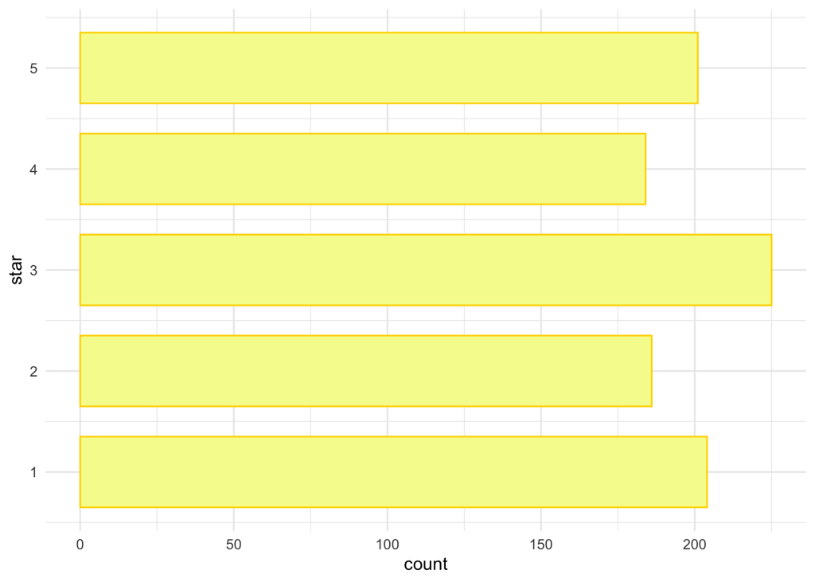

```r
ggplot(usr_feedback, aes(star)) + geom_bar(colour = "gold", fill = "#F5FA9B", width = 0.7)+ theme_minimal() + coord_flip()
```

Il serait assez intéressant d’avoir des commentaires, tout du moins pour certains individus, afin de permettre de travailler le traitement de données textuelles.

### 2.3.4 `fake_survey_answer()` et `fake_survey_people()`

Ces fonctions sont un petit peu plus complète que les précédentes:

- ‘fake_survey_answer()’ renvoie un jeu de données factice de réponse à 3 formulaires de questions (3 lignes par indivus) sur les déplacement, et ce accompagné certaines variables individuelles (id, sexe et département/région).

```r
survey_a <- fake_survey_answers(n = 300, split = FALSE, seed = 2023)
survey_a
```

```
# A tibble: 900 × 12
   id_individu    age sexe  region               id_departement nom_departement
   <chr>        <int> <chr> <chr>                <chr>          <chr>
 1 ID-SXEM-0155    NA F     Languedoc-Roussillon 34             Hérault
 2 ID-SXEM-0155    NA F     Languedoc-Roussillon 34             Hérault
 3 ID-SXEM-0155    NA F     Languedoc-Roussillon 34             Hérault
 4 ID-ZOUR-0016    NA F     <NA>                 21             <NA>
 5 ID-ZOUR-0016    NA F     <NA>                 21             <NA>
 6 ID-ZOUR-0016    NA F     <NA>                 21             <NA>
 7 ID-IRGX-0008    80 M     Midi-Pyrénées        82             <NA>
 8 ID-IRGX-0008    80 M     Midi-Pyrénées        82             <NA>
 9 ID-IRGX-0008    80 M     Midi-Pyrénées        82             <NA>
10 ID-NFIQ-0147    72 <NA>  Poitou-Charentes     79             <NA>
# ℹ 890 more rows
# ℹ 6 more variables: question_date <dttm>, year <dbl>, type <chr>,
#   distance_km <dbl>, transport <fct>, temps_trajet_en_heures <dbl>
```

```r
summary(survey_a)
```

```
 id_individu             age            sexe              region
 Length:900         Min.   :18.00   Length:900         Length:900
 Class :character   1st Qu.:35.00   Class :character   Class :character
 Mode  :character   Median :57.00   Mode  :character   Mode  :character
                    Mean   :56.39
                    3rd Qu.:76.00
                    Max.   :95.00
                    NA's   :69
 id_departement     nom_departement    question_date
 Length:900         Length:900         Min.   :2016-09-24 09:46:06.27
 Class :character   Class :character   1st Qu.:2021-07-10 19:18:37.06
 Mode  :character   Mode  :character   Median :2022-05-16 04:51:40.97
                                       Mean   :2022-03-09 16:35:18.99
                                       3rd Qu.:2023-03-05 00:51:16.50
                                       Max.   :2023-09-30 23:59:58.00

      year          type            distance_km           transport
 Min.   :2016   Length:900         Min.   :   1.157   voiture  :375
 1st Qu.:2021   Class :character   1st Qu.:  10.114   train    :272
 Median :2022   Mode  :character   Median :  30.444   mobylette: 86
 Mean   :2022                      Mean   : 103.932   velo     : 85
 3rd Qu.:2023                      3rd Qu.: 136.666   bus      : 46
 Max.   :2023                      Max.   :1347.039   avion    : 29
                                                      (Other)  :  7
 temps_trajet_en_heures
 Min.   :0.1200
 1st Qu.:0.2700
 Median :0.4400
 Mean   :0.4965
 3rd Qu.:0.7300
 Max.   :1.0800
```

- ‘fake_survey_people()’ renvoie une base de `n` lignes listant les individus et leurs caractéristiques sans les réponses.

```r
survey_p <- fake_survey_people(n = 300, seed = 2023)
survey_p
```

```
# A tibble: 300 × 8
   id_individu    age sexe  region                id_departement nom_departement
   <chr>        <int> <chr> <chr>                 <chr>          <chr>
 1 ID-SXEM-0155    NA F     Provence-Alpes-Côte … 06             Alpes-Maritimes
 2 ID-ZOUR-0016    NA F     <NA>                  67             Bas-Rhin
 3 ID-IRGX-0008    80 M     Centre                28             Eure-et-Loir
 4 ID-NFIQ-0147    72 <NA>  Lorraine              55             Meuse
 5 ID-VAHB-0178    80 M     Rhône-Alpes           73             Savoie
 6 ID-AZJG-0189    38 F     Aquitaine             33             Gironde
 7 ID-EXIL-0173    72 O     Poitou-Charentes      17             Charente-Marit…
 8 ID-ENUF-0191    24 F     Alsace                68             Haut-Rhin
 9 ID-JOSX-0096    28 F     Midi-Pyrénées         65             Hautes-Pyrénées
10 ID-KEOG-0077    26 O     Basse-Normandie       50             Manche
# ℹ 290 more rows
# ℹ 2 more variables: question_date <dttm>, year <dbl>
```

```r
summary(survey_p)
```

```
 id_individu             age            sexe              region
 Length:300         Min.   :18.00   Length:300         Length:300
 Class :character   1st Qu.:35.00   Class :character   Class :character
 Mode  :character   Median :57.00   Mode  :character   Mode  :character
                    Mean   :56.39
                    3rd Qu.:76.00
                    Max.   :95.00
                    NA's   :23
 id_departement     nom_departement    question_date
 Length:300         Length:300         Min.   :2016-09-24 09:46:06.32
 Class :character   Class :character   1st Qu.:2021-07-10 19:18:37.11
 Mode  :character   Mode  :character   Median :2022-05-16 04:51:41.01
                                       Mean   :2022-03-09 16:35:19.04
                                       3rd Qu.:2023-03-05 00:51:16.55
                                       Max.   :2023-09-30 23:59:58.05

      year
 Min.   :2016
 1st Qu.:2021
 Median :2022
 Mean   :2022
 3rd Qu.:2023
 Max.   :2023
```

Ces deux fonctions acceptent des paramètres semblables aux précédentes : `n`et la `seed`. `fake_survey_answer()` permet d’obtenir les bases jointes (individus et réponses) ou disjointes (deux bases séparée) selon l’option `split = TRUE` ou `split = FALSE` comme nous pouvons le voir ci-dessous.

```r
survey <- fake_survey_answers(n = 300, split = TRUE, seed = 2023)
survey
```

```
$individus
# A tibble: 300 × 8
   id_individu    age sexe  region                id_departement nom_departement
   <chr>        <int> <chr> <chr>                 <chr>          <chr>
 1 ID-SXEM-0155    NA F     Provence-Alpes-Côte … 83             Var
 2 ID-ZOUR-0016    NA F     Lorraine              54             Meurthe-et-Mos…
 3 ID-IRGX-0008    80 M     Provence-Alpes-Côte … 84             <NA>
 4 ID-NFIQ-0147    72 <NA>  <NA>                  23             Creuse
 5 ID-VAHB-0178    80 M     <NA>                  39             <NA>
 6 ID-AZJG-0189    38 F     Île-de-France         94             Val-de-Marne
 7 ID-EXIL-0173    72 O     Centre                18             Cher
 8 ID-ENUF-0191    24 F     Rhône-Alpes           73             Savoie
 9 ID-JOSX-0096    28 F     Rhône-Alpes           26             Drôme
10 ID-KEOG-0077    26 O     Midi-Pyrénées         46             Lot
# ℹ 290 more rows
# ℹ 2 more variables: question_date <dttm>, year <dbl>

$answers
# A tibble: 900 × 5
   id_individu  type      distance_km transport temps_trajet_en_heures
   <chr>        <chr>           <dbl> <fct>                      <dbl>
 1 ID-SXEM-0155 travail          9.51 bus                         0.89
 2 ID-SXEM-0155 commerces       22.2  voiture                     0.3
 3 ID-SXEM-0155 loisirs         97.4  train                       0.19
 4 ID-ZOUR-0016 travail          8.94 bus                         0.95
 5 ID-ZOUR-0016 commerces       27.4  voiture                     0.34
 6 ID-ZOUR-0016 loisirs        577.   avion                       0.29
 7 ID-IRGX-0008 travail          3.47 velo                        0.65
 8 ID-IRGX-0008 commerces       43.8  voiture                     0.6
 9 ID-IRGX-0008 loisirs        142.   train                       0.29
10 ID-NFIQ-0147 travail          4.83 velo                        1.03
# ℹ 890 more rows
```

On peut donc faire des jointures sur les bases si besoin :

```r
survey_merged <- merge(survey$individus,survey$answers,by="id_individu")
as_tibble(survey_merged)
```

```
# A tibble: 900 × 12
   id_individu    age sexe  region            id_departement nom_departement
   <chr>        <int> <chr> <chr>             <chr>          <chr>
 1 ID-AFDY-0010    40 O     Picardie          80             Somme
 2 ID-AFDY-0010    40 O     Picardie          80             Somme
 3 ID-AFDY-0010    40 O     Picardie          80             Somme
 4 ID-AFZS-0112    26 O     Auvergne          63             Puy-de-Dôme
 5 ID-AFZS-0112    26 O     Auvergne          63             Puy-de-Dôme
 6 ID-AFZS-0112    26 O     Auvergne          63             Puy-de-Dôme
 7 ID-AGKE-0271    69 M     Champagne-Ardenne 51             Marne
 8 ID-AGKE-0271    69 M     Champagne-Ardenne 51             Marne
 9 ID-AGKE-0271    69 M     Champagne-Ardenne 51             Marne
10 ID-AGQK-0225    NA F     Basse-Normandie   61             Orne
# ℹ 890 more rows
# ℹ 6 more variables: question_date <dttm>, year <dbl>, type <chr>,
#   distance_km <dbl>, transport <fct>, temps_trajet_en_heures <dbl>
```

Cette fonction nous renvoie un *dataset* qui paraît assez réaliste (bien que les données semblent très peu bruitées) avec des corrélations claires entre les différentes variables et donc plutôt intéressantes pour travailler la visualisation.

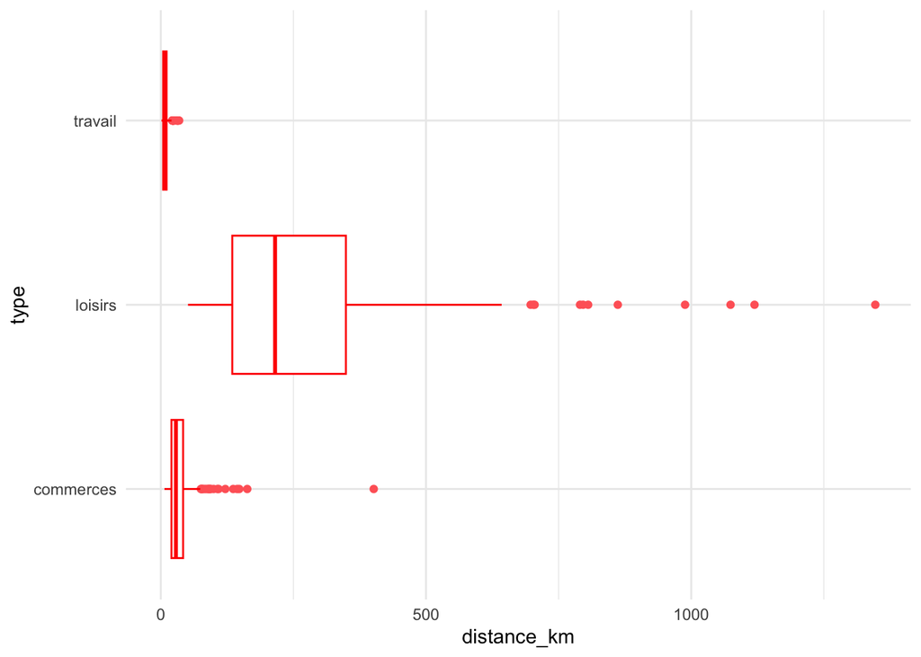

```r
ggplot(survey_merged, aes(x=type, y=distance_km))+
geom_boxplot(color="red",outlier.color="#FF6666") +
theme_minimal() +
coord_flip()
```

Il est possible de réaliser des choses relativement intéressantes comme nous pouvons voir ci-dessous.

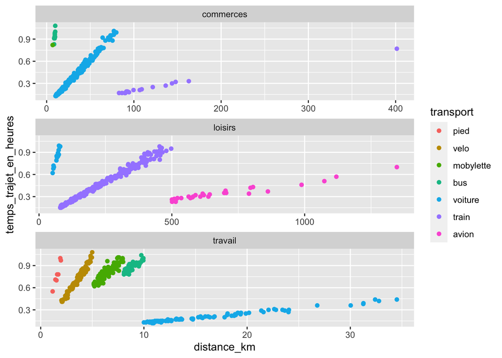

```r
graph <- ggplot(survey_merged, aes(x = distance_km, y = temps_trajet_en_heures)) +  geom_point(aes(color = transport))
graph + facet_wrap(~type, ncol = 1, scales = "free_x")
```

Ici par exemple, on note bien les différences en terme de moyens de transports utilisés selon le type de besoin et la corrélation entre temps et distance.

### 2.3.5 `fake_base_clients` et `fake_ticket_client`

Ici, nous avons affaire à des fonctions renvoyant une base de données client (nom, age, emploi, département, type de carte, statut de fidélité) et une liste de ticket au support d’une entreprise de télécom. Il est possible de les obtenir jointes ou disjointes et d’en déterminer le nombre d’observations (`n`pour le nombre d’individus et `vol` pour le nombre de tickets).

```r
client_ticket <- fake_ticket_client(1000, n = 500, split = TRUE, local = "fr_FR", seed=2023)
client_ticket
```

```
$clients
# A tibble: 500 × 14
   num_client prenom nom   job     age region id_dpt departement gestionnaire_cb
 * <chr>      <chr>  <chr> <chr> <dbl> <chr>  <chr>  <chr>       <chr>
 1 1          Anouk  Mart… Ingé…    25 Bourg… 89     Yonne       Discover
 2 2          Chris… d'Au… Audi…    46 Nord-… 59     Nord        <NA>
 3 3          Édith  Réna… Cons…    58 Centre 41     Loir-et-Ch… <NA>
 4 4          Nicole d'Fi… Cons…    36 Haute… 27     Eure        <NA>
 5 5          Jacqu… L'Ri… Visi…    51 Haute… 27     Eure        Maestro
 6 6          Arthur Laur… <NA>     38 Breta… 22     Côtes-d'Ar… JCB 16 digit
 7 7          Marga… Jaco… Ingé…    19 Prove… 84     Vaucluse    Mastercard
 8 8          David  Lopé… Cond…    46 Haute… 27     Eure        <NA>
 9 9          Nicol… Turp… Vend…    47 <NA>   76     Seine-Mari… <NA>
10 10         Susan… Lamy  Garde    37 Poito… 16     Charente    <NA>
# ℹ 490 more rows
# ℹ 5 more variables: nom_complet <chr>, entry_date <dttm>,
#   points_fidelite <dbl>, priorite_encodee <dbl>, priorite <fct>

$tickets
# A tibble: 1,000 × 10
   ref        num_client annee  mois  jour timestamp  pris_en_charge type  etat
   <chr>      <chr>      <dbl> <dbl> <int> <date>     <chr>          <chr> <fct>
 1 DOSS-ZFVJ… 2           2018     8    22 2018-08-22 Oui            Ligne Term…
 2 DOSS-VUTR… 2           2018    11    27 2018-11-27 Non            Ligne En c…
 3 DOSS-MROS… 7           2019     2     2 2019-02-02 Oui            Box   Inte…
 4 DOSS-JDYN… 7           2019     3    22 2019-03-22 Oui            Inst… En c…
 5 DOSS-OLUD… 7           2019     6    18 2019-06-18 Non            Box   Term…
 6 DOSS-JAXY… 6           2019     8     4 2019-08-04 Non            Box   Inte…
 7 DOSS-MICA… 8           2019     9     3 2019-09-03 Oui            Ligne En c…
 8 DOSS-TSAV… 5           2019     9     6 2019-09-06 Oui            Box   Inte…
 9 DOSS-UTKD… 9           2019     9    15 2019-09-15 Non            Ligne En c…
10 DOSS-LSYT… 15          2019     9    21 2019-09-21 Non            Ligne Atte…
# ℹ 990 more rows
# ℹ 1 more variable: source_appel <fct>
```

```r
fake_base_clients(500, local = "en_US")
```

```
# A tibble: 500 × 14
   num_client first   last     job     age region id_dpt departement cb_provider
 * <chr>      <chr>   <chr>    <chr> <dbl> <chr>  <chr>  <chr>       <chr>
 1 1          Laken   McDermo… Clin…    50 Breta… 35     Ille-et-Vi… Diners Clu…
 2 2          Dr.     KamariK… Educ…    66 <NA>   73     Savoie      JCB 15 dig…
 3 3          Ciarra  Willms   Comm…    64 <NA>   62     Pas-de-Cal… Mastercard
 4 4          Dr.     JoyPadb… Cons…    79 <NA>   44     Loire-Atla… VISA 16 di…
 5 5          Miss    MellieK… Engi…    54 Limou… 23     Creuse      American E…
 6 6          Miss    Krystin… Fiel…    68 Île-d… 75     Paris       VISA 16 di…
 7 7          Kristin DuBuque  Envi…    18 Poito… 86     Vienne      JCB 16 dig…
 8 8          Dr.     OlinHer… Bari…    32 Auver… 15     Cantal      Voyager
 9 9          Mr.     BorisSe… Scie…    46 Pays … 53     Mayenne     VISA 16 di…
10 10         Rowan   Mraz     Opti…    18 Île-d… 78     Yvelines    VISA 16 di…
# ℹ 490 more rows
# ℹ 5 more variables: name <chr>, entry_date <dttm>, fidelity_points <dbl>,
#   priority_encoded <dbl>, priority <fct>
```

Nous pouvons décider d’avoir les noms et profession en anglais ou français avec le paramètre `local`. Malheureusement, la localisation géographique ne s’adapte pas au cas américain comme visible ci-dessus…

Le package inclut aussi une carte des départements français comme objet du package `sf` ce qui permet de faciliter la représentation cartographique des données factices crées sur R.

```r
# code repris presque directement du wiki de fakir (https://thinkr-open.github.io/fakir/)
library(sf)
client_map <- as.data.frame(client_ticket$clients) %>%  group_by(id_dpt) %>%  summarise(number_of_clients = n()) %>% full_join(fra_sf, by = "id_dpt") %>% st_sf()
```

```
old-style crs object detected; please recreate object with a recent sf::st_crs()
```

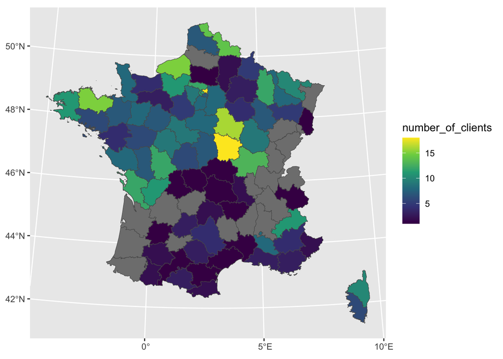

```r
ggplot(client_map) + geom_sf(aes(fill = number_of_clients)) + scale_fill_viridis_c() + coord_sf(crs = 2154, datum = 4326)
```

On peut ainsi voir par exemple le nombre de client par département. Malheureusement les résultats ne sont pas reproductibles, la seed ne fixant pas le département des individus de la base (nom, age, sexe et statut de fidélité sont eux bien fixés par la `seed`).

## 2.4 résumé des fonctions et de paramètres

Nous pouvons voir que les fonctions renvoient 5 types de jeu de données différents :

- une fausse liste de produits (`fake_product()`)
- un faux registre des visites quotidiennes sur un site (`fake_visits()`)
- un fausse liste d’évaluation par les clients (`fake_user_feedback()`)
- les fausses réponses à sondage sur les habitudes de transport (`fake_survey_people()` pour avoir juste les répondants ou `fake_survey_answer()` les répondants et leur réponses)
- une fausse base de clients et leur tickets pour un service de support (`fake base_clients()` pour avoir juste une liste de clients ou `fake_ticket_client()` pour avoir les clients et leur ticket)

Pour schématiser, 4 différents arguments peuvent être envoyés aux fonctions :

- `seed` permet de déterminer l’initialisation du générateur pseudo-aléatoire afin d’avoir des résultats réplicable (si utilisation de la même graine), elle dispose d’une valeur par défaut de 2811.
- `n` pour selectionner le nombre de ligne du jeu de données en sortie (pour `fake_visits()` c’est la date de début et la date de fin qui détermine n)
- `local` permet de choisir entre avoir les données avec des informations (nom, prénom) françaises ou étasuniennes pour des faux-client [^5].
- `split` qui, pour les jeux de données qui sont issus de jointure (client et leurs ticket pour `fake_client_...()`, réponse et répondants pour `fake_survey_...()`), permet de choisir si l’on veut deux base (`split = TRUE`) ou une seule (`split = FALSE`)

# 3. Les autres options pour avoir des données utilisables à des fins pédagogiques

## 3.1 les jeux de données *“built-in”* ou de packages

La distribution R vient avec plusieurs jeux de données utilisables à des fins pédagogiques. Les plus connus sont iris (et sa fameuse variable Sepal.Length et Sepal.Width) ou mtcars. D’autres peuvent aussi venir avec certains packages ([dplyr](https://cran.r-project.org/web/packages/dplyr/index.html), [palmerpinguins](https://cran.r-project.org/web/packages/palmerpenguins/index.html)…). La commande `data()` permet d’en obtenir la liste accessible dans l’environnement de travail.

Cependant, ces *datasets* sont souvent à un niveau d’observation agrégé (régional…) ou peu applicables à des cas pratiques et aux besoins réels. De plus, elles sont généralement nettoyées et ne permettent donc de travailler les compétences *data wrangling* (gérer les valeurs manquantes, les jointures, les chaînes de caractères) dans un cadre pédagogique.

## 3.2 créer un jeu de données *“from scratch”*

Certains packages R ([charlatan](https://cran.r-project.org/web/packages/charlatan/index.html)[^6], [ids](https://cran.r-project.org/web/packages/ids/index.html) ou [wakefield](https://cran.r-project.org/web/packages/wakefield/index.html) par exemple) permettent de générer des données aléatoires préformatées (numéros de téléphones, nom, adresses, id…). Ainsi en multipliant les données aléatoires de différents types, on peut s’approcher de jeux de données réalistes. Comme fakir ces packages permettent aussi de créer des données manquantes.

Ces packages sont très pratiques pour créer des jeux de données factices parfaitement adaptés aux besoins mais sont plus complexes et long à mettre en place. De plus, ils ne permettent pas souvent d’avoir facilement des structures de dépendance au sein des données (corrélation…) comme fakir le permet [^7].

## 3.3 forces de fakir et futures améliorations

Ces autres options permettent de mieux percevoir les avantages et les limites de fakir. Il est plus adapté aux besoins pratiques et aux objectifs pédagogiques que les *datasets* déjà présents dans R, et plus simple d’utilisation que les packages permettant de créer des données factices en partant de 0 tout en permettant d’avoir certaines structure de dépendance rendant les données en partie exploitables pour l’apprentissage et la visualisation.

Cependant, il convient aussi de noter que certaines données générées semblent parfois un peu étonnantes (`fake_client()` ou `fake_products()` par exemple) et il souvent possible de déterminer le *data generating process* sous-jacent ce qui peut limiter l’intérêt pour modéliser (de réelles bases de données sont plus intéressantes dans cette perspective).

En explorant les [conversations des contributeurs](https://github.com/ThinkR-open/fakir/issues/), on peut voir les différentes idées de développements ultérieurs autour de fakir. L’idée principale est l’amélioration et l’ajout de générateur de données traduites (l’essentiel des jeux sont adaptés au cas français avec région, départements, nom et prenoms). Certaines bases sont déjà accessibles avec des données adaptées pour les États-Unis, mais beaucoup de travail reste à faire à ce niveau. Les contributeurs pensent aussi ajouter certaines bases de données sur d’autres sujets (tweets, films, sports…) mais nous n’avons pas plus d’informations à ce stade.

# 4. Sources

Fay C, Rochette S (2023). CRAN repository : *fakir: Generate Fake Datasets for Prototyping and Teaching*. R package version 1.0.0, https://cran.r-project.org/web/packages/fakir/index.html.

Fay C, Rochette S (2023). Code & git repository : *fakir: Create Fake Data in R for tutorials*. R package version 1.0.0, https://github.com/Thinkr-open/fakir.

Fay C, Rochette S (2023). Docs *Package ‘fakir’ - user guide,* https://cran.r-project.org/web/packages/fakir/fakir.pdf.

Abdul Majed Raja (2019). Blog : *Create fake but meaningful data using {fakir},* https://towardsdatascience.com/create-fake-but-meaningful-data-using-fakir-b193df1f4c94.

Dima Diachkov (2023). Blog : *How to create purely fictional datasets in R with the fakir package,* https://blog.devgenius.io/how-to-create-purely-fictional-datasets-in-r-with-fakir-package-5c527516c682 .

Abdul Majed Raja, alias 1littlecoder (2020). Vidéo : *Create meaningful fake tidy datasets in R using fakir [#rstats Package],* https://www.youtube.com/watch?v=EhhljL5zaWs.

## Notes de bas de page

[^1]: Dernière modification le 13/04/2023.
[^2]: Le manuel est aussi dans le dépôt du didacticiel 3.
[^3]: L’auteur du package parle très clairement de faciliter le “prototypage” d’applications shiny comme un objectif principal de fakir dans [cette conversation](https://github.com/ThinkR-open/fakir/issues/2#issuecomment-932380491)
[^4]: Les fonctions `fake_sondage_...()` sont dîtes *deprecated* (donc à ne pas utiliser), et ont été remplacées par `fake_survey_...()`.
[^5]: Il est dommage que cette fonctionnalité soit applicable uniquement pour 2 *datasets* et ne change pas la région et le département pour l’adapter au cas étasunien.
[^6]: Ce package est utilisé par fakir pour créer certaines données aléatoires. Il est très similaire au package Python nommée [Faker](https://pypi.org/project/Faker/).
[^7]: Dans cette perspective, [synthpop](https://cran.r-project.org/web/packages/synthpop/index.html) peut être intéressant, c’est un package qui construit des données de synthèse se basant sur des données micro réelles.